# Ranked Choice Voting in the 2025 Santa Fe Mayoral Race

2025-12-14

## Introduction

This post uses official results from the 2025 Santa Fe mayoral race to walk through how **ranked choice voting** (RCV) data is structured – tracking vote counts and transfers across elimination rounds, where the last-place candidate is repeatedly dropped and their ballots redistributed to voters’ next-ranked choice until someone clears 50%, and pulling the full process into a **Sankey diagram**.

## Data

This analysis uses official Ranked Choice Voting data from the 2025 Santa Fe mayoral race. The data are available in the newmexico-political-data package on GitHub: RcvShortReport-CC2.csv. The raw data has a pretty nasty structure – it’s in **wide format** with separate columns for each round (e.g., `round1_votes`, `round2_votes`, `round3_votes`, etc.), making it difficult to work with directly. We restructure this data throughout the analysis to make it more manageable for visualization.

The original data structure includes:

- `candidate`: Candidate name
- `roundX_votes`: Vote count for each candidate in round X
- `roundX_pct`: Percentage of votes in round X
- `roundX_transfer`: Votes transferred in round X (positive = received, negative = eliminated)

For the visualizations, we reshape this wide format into **long format** (one row per candidate per round) and calculate **vote transfers** by comparing vote changes between rounds.

```r
pacman::p_load(dplyr, ggplot2, tidyr, forcats, purrr, ggalluvial, ggthemes, DT, htmltools, knitr, scales, gt, networkD3, htmlwidgets)
```

```r
# Read the CSV file
rcv_data <- read.csv("/home/jtimm/Dropbox/GitHub/git-projects/newmexico-political-data/data/sf-rcv/RcvShortReport-CC2.csv", stringsAsFactors = FALSE)

# Display the raw data
DT::datatable(
  rcv_data,
  caption = htmltools::tags$caption(
    style = 'caption-side: top; text-align: left;',
    'Raw RCV Election Data: All rounds and vote transfers'
  ),
  options = list(
    scrollX = TRUE,
    pageLength = 10,
    dom = 'frtip'
  ),
  rownames = FALSE
)
```

| candidate | round1_votes | round1_pct | round1_transfer | round2_votes | round2_pct | round2_transfer | round3_votes | round3_pct | round3_transfer | round4_votes | round4_pct | round4_transfer | round5_votes | round5_pct | round5_transfer | round6_votes | round6_pct | round6_transfer | round7_votes | round7_pct |
| --- | --- | --- | --- | --- | --- | --- | --- | --- | --- | --- | --- | --- | --- | --- | --- | --- | --- | --- | --- | --- |
| JUSTIN S GREENE | 2452 | 9.98 | 19 | 2471 | 10.07 | 75 | 2546 | 10.42 | 263 | 2809 | 11.57 | 317 | 3126 | 13.21 | -3126 | 0 | 0 | 0 | 0 | 0 |
| MICHAEL J GARCIA | 8838 | 35.97 | 14 | 8852 | 36.06 | 147 | 8999 | 36.83 | 452 | 9451 | 38.93 | 673 | 10124 | 42.79 | 1243 | 11367 | 49.42 | 2033 | 13400 | 62.77 |
| LETITIA MONTOYA | 713 | 2.9 | 10 | 723 | 2.95 | -723 | 0 | 0 | 0 | 0 | 0 | 0 | 0 | 0 | 0 | 0 | 0 | 0 | 0 | 0 |
| OSCAR SALAZAR RODRIGUEZ | 5536 | 22.53 | 17 | 5553 | 22.62 | 80 | 5633 | 23.05 | 476 | 6109 | 25.16 | 240 | 6349 | 26.84 | 861 | 7210 | 31.35 | 737 | 7947 | 37.23 |
| JOANNE VIGIL COPPLER | 1921 | 7.82 | 15 | 1936 | 7.89 | 124 | 2060 | 8.43 | 211 | 2271 | 9.35 | -2271 | 0 | 0 | 0 | 0 | 0 | 0 | 0 | 0 |
| RONALD S TRUJILLO | 3426 | 13.94 | 9 | 3435 | 13.99 | 98 | 3533 | 14.46 | 104 | 3637 | 14.98 | 422 | 4059 | 17.16 | 364 | 4423 | 19.23 | -4423 | 0 | 0 |
| TARIN J NIX | 1558 | 6.34 | 21 | 1579 | 6.43 | 84 | 1663 | 6.81 | -1663 | 0 | 0 | 0 | 0 | 0 | 0 | 0 | 0 | 0 | 0 | 0 |
| JEANNE M O'DEAN | 126 | 0.51 | -126 | 0 | 0 | 0 | 0 | 0 | 0 | 0 | 0 | 0 | 0 | 0 | 0 | 0 | 0 | 0 | 0 | 0 |

```r
# Calculate total votes
total_votes <- sum(rcv_data$round1_votes)

# Create consistent color mapping for candidates (used across all plots)
# Order by round 1 votes (descending) to match Sankey order
candidate_order_colors <- rcv_data |>
  select(candidate, round1_votes) |>
  arrange(desc(round1_votes)) |>
  pull(candidate)

candidate_colors <- ggthemes::stata_pal()(nrow(rcv_data))
names(candidate_colors) <- candidate_order_colors
```

## Initial Vote Distribution (Round 1)

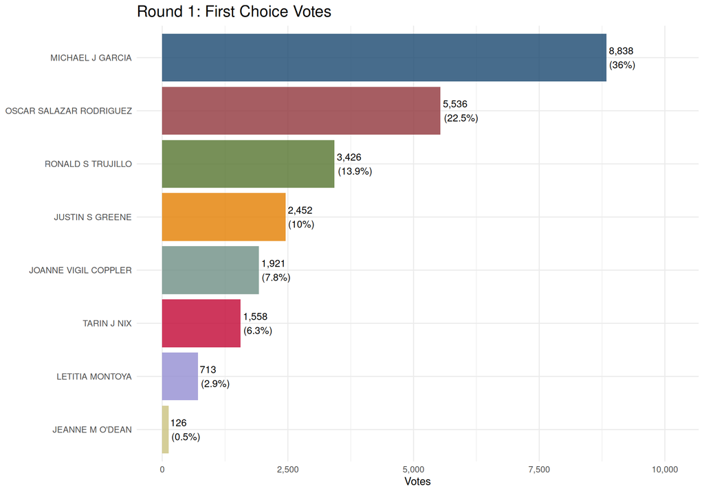

```r
rcv_data |>
  arrange(desc(round1_votes)) |>
  mutate(candidate = forcats::fct_reorder(candidate, round1_votes)) |>
  ggplot(aes(x = candidate, y = round1_votes, fill = candidate)) +
  geom_col(alpha = 0.8) +
  geom_text(aes(label = paste0(scales::comma(round1_votes), "\n(",
                               round(round1_pct, 1), "%)")),
            hjust = -0.1, size = 3.5) +
  geom_hline(yintercept = total_votes / 2, linetype = "dashed",
             color = "grey", linewidth = 1) +
  annotate("text", x = 7, y = total_votes / 2 + 500,
           label = paste0("50% threshold: ", scales::comma(ceiling(total_votes/2)), " votes"),
           color = "red", size = 4) +
  coord_flip() +
  scale_y_continuous(labels = scales::comma, limits = c(0, max(rcv_data$round1_votes) * 1.15)) +
  scale_fill_manual(values = candidate_colors) +
  labs(title = "Round 1: First Choice Votes",
       x = NULL, y = "Votes") +
  theme_minimal() +
  theme(legend.position = "none",
        plot.title = element_text(size = 16))
```

## Track Vote Proportions Across Rounds

This stacked bar chart shows how the proportion of votes held by each candidate changes as elimination rounds progress, with **transferred votes gradually pushing the eventual winner above the majority line**. The grey dashed line indicates the 50% threshold needed to win.

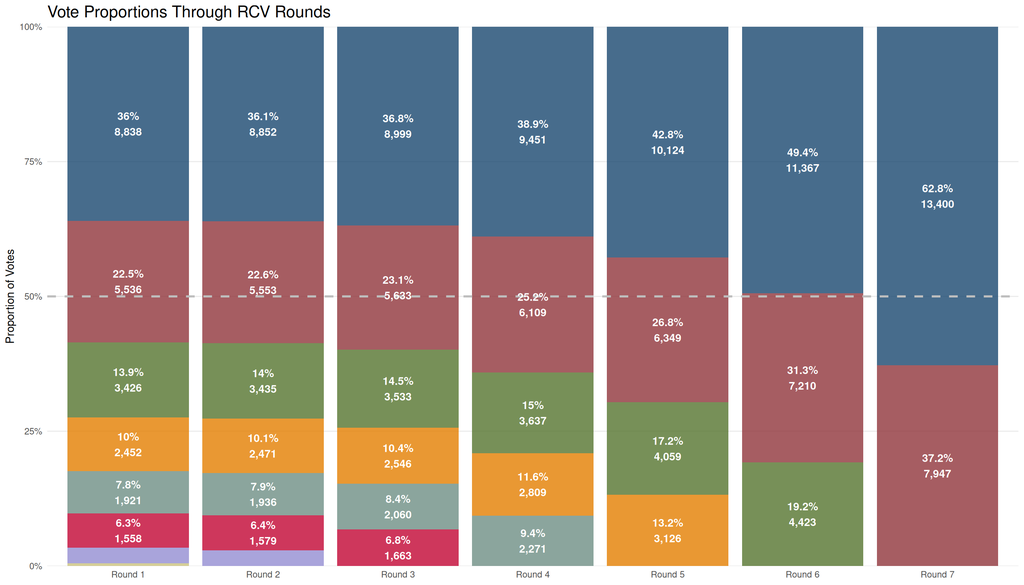

```r
# Prepare data for proportion plot showing vote percentages
round_cols <- names(rcv_data)[grepl("^round\\d+_votes$", names(rcv_data))]
round_nums <- as.integer(gsub("^round(\\d+)_votes$", "\\1", round_cols))
round_nums <- sort(round_nums)

# Order candidates by round 1 votes (same as Sankey)
candidate_order_prop <- rcv_data |>
  select(candidate, round1_votes) |>
  arrange(desc(round1_votes)) |>
  pull(candidate)

# Pivot to long format and calculate proportions
proportion_long <- rcv_data |>
  select(candidate, all_of(paste0("round", round_nums, "_votes"))) |>
  tidyr::pivot_longer(cols = starts_with("round"),
               names_to = "round",
               values_to = "votes") |>
  filter(votes > 0) |>
  mutate(round_num = as.integer(gsub("round(\\d+)_votes", "\\1", round)),
         round = factor(paste0("Round ", round_num),
                       levels = paste0("Round ", round_nums))) |>
  group_by(round) |>
  mutate(
    total_votes = sum(votes),
    proportion = votes / total_votes,
    pct = proportion * 100
  ) |>
  ungroup() |>
  # Order candidates by round 1 votes
  mutate(candidate = factor(candidate, levels = candidate_order_prop))

# Create proportion plot (stacked area or bars)
ggplot(proportion_long,
       aes(x = round, y = proportion, fill = candidate)) +
  geom_col(position = "stack", alpha = 0.8) +
  geom_hline(yintercept = 0.5, linetype = "dashed",
             color = "grey", linewidth = 1) +
  geom_text(aes(label = ifelse(pct > 3,
                               paste0(round(pct, 1), "%\n", scales::comma(votes)),
                               "")),
            position = position_stack(vjust = 0.5),
            size = 3.75,
            color = "white",
            fontface = "bold") +
  scale_fill_manual(values = candidate_colors) +
  scale_y_continuous(labels = scales::percent_format(),
                     expand = c(0, 0)) +
  labs(title = "Vote Proportions Through RCV Rounds",
       x = NULL,
       y = "Proportion of Votes",
       fill = "Candidate") +
  theme_minimal() +
  theme(legend.position = "none",
        plot.title = element_text(size = 16),
        panel.grid.major.x = element_blank(),
        panel.grid.minor = element_blank())
```

## Build the Sankey Diagram

The **Sankey diagram** below visualizes how votes flow from eliminated candidates to remaining candidates across all rounds. Each flow represents votes being transferred, with the width proportional to the number of votes.

### Build Nodes and Links

For each round transition we create two types of flows: - **Maintained votes**: a candidate’s round-r votes carry forward to round r+1 - **Transferred votes**: the eliminated candidate’s votes flow to gainers, using the actual `transfer` column from the raw data

```r
rcv_long <- rcv_data |>
  tidyr::pivot_longer(
    cols = -candidate,
    names_to = c("round", ".value"),
    names_pattern = "round(\\d+)_(.*)"
  ) |>
  mutate(round = as.integer(round))

max_round <- max(rcv_long$round, na.rm = TRUE)

candidate_order <- rcv_data |>
  arrange(desc(round1_votes)) |>
  pull(candidate)

links_df <- purrr::map_dfr(seq_len(max_round - 1), function(r) {
  curr <- filter(rcv_long, round == r, votes > 0)
  nxt  <- filter(rcv_long, round == r + 1, votes > 0)
  eliminated <- setdiff(curr$candidate, nxt$candidate)

  bind_rows(
    # maintained votes
    curr |>
      filter(!candidate %in% eliminated) |>
      transmute(source = paste0(candidate, "_R", r),
                target = paste0(candidate, "_R", r + 1),
                value  = votes),
    # transfers — read directly from the transfer column
    nxt |>
      filter(transfer > 0) |>
      transmute(source = paste0(eliminated[1], "_R", r),
                target = paste0(candidate, "_R", r + 1),
                value  = transfer)
  )
})

nodes_df <- data.frame(name = unique(c(links_df$source, links_df$target))) |>
  mutate(candidate = gsub("_R\\d+$", "", name),
         round_num = as.integer(gsub(".*_R", "", name))) |>
  arrange(match(candidate, candidate_order), round_num)

links_df <- links_df |>
  mutate(IDsource = match(source, nodes_df$name) - 1,
         IDtarget = match(target, nodes_df$name) - 1)

color_domain   <- paste0('"', candidate_order, '"', collapse = ",")
color_range    <- paste0('"', candidate_colors[candidate_order], '"', collapse = ",")
color_scale_js <- paste0("d3.scaleOrdinal().domain([", color_domain, "]).range([", color_range, "])")
```

### Render the Sankey Diagram

The Sankey diagram below visualizes how votes flow from eliminated candidates to remaining candidates across all rounds. Each flow represents votes being transferred, with **the width proportional to the number of votes**.

```r
p <- networkD3::sankeyNetwork(
  Links = links_df,
  Nodes = nodes_df,
  Source = "IDsource",
  Target = "IDtarget",
  Value = "value",
  NodeID = "name",
  NodeGroup = "candidate",
  colourScale = htmlwidgets::JS(color_scale_js),
  sinksRight = TRUE,
  iterations = 0,
  fontSize = 12,
  nodeWidth = 25,
  width = 1200,
  height = 900
)

# Clean labels and make fully responsive
p <- htmlwidgets::onRender(p, '
function(el, x) {
  // Clean labels
  d3.select(el).selectAll(".node text").text(function(d) {
    if (d.name.endsWith("_R1")) {
      var name = d.name.replace(/_R1$/, "");
      var parts = name.trim().split(" ");
      return parts[parts.length - 1].toUpperCase();
    }
    return "";
  });

  // Get container and SVG - set to 100% immediately
  var container = el.closest(".html-widget-container") || el.parentElement;
  if (container) {
    container.style.width = "100%";
    container.style.maxWidth = "100%";
  }
  el.style.width = "100%";

  var svg = d3.select(el).select("svg");
  if (svg.empty()) return;

  // Function to update size - use 100% of container
  function updateSize() {
    // Get the width of the post content container
    var postContent = document.querySelector(".post-content") ||
                     document.querySelector(".container") ||
                     document.querySelector(".site-main") ||
                     document.body;
    var containerWidth = postContent.offsetWidth || window.innerWidth;

    // Also check the html-widget-container directly
    if (container && container.offsetWidth > 0) {
      containerWidth = Math.max(containerWidth, container.offsetWidth);
    }

    if (containerWidth > 0) {
      // Get aspect ratio from current SVG or use default
      var currentWidth = parseInt(svg.attr("width")) || containerWidth;
      var currentHeight = parseInt(svg.attr("height")) || 500;
      var aspectRatio = currentHeight / currentWidth;

      // Use full container width
      var newWidth = containerWidth;
      var newHeight = newWidth * aspectRatio;

      svg.attr("width", newWidth)
         .attr("height", newHeight);

      // Update the widget element size
      el.style.width = "100%";
      el.style.height = newHeight + "px";
    }
  }

  // Initial size update
  setTimeout(updateSize, 100);

  // Use ResizeObserver for better resize detection
  if (window.ResizeObserver) {
    var targetContainer = container || el.parentElement || document.body;
    var resizeObserver = new ResizeObserver(function(entries) {
      updateSize();
    });
    resizeObserver.observe(targetContainer);
  } else {
    // Fallback to window resize
    var resizeTimer;
    window.addEventListener("resize", function() {
      clearTimeout(resizeTimer);
      resizeTimer = setTimeout(updateSize, 100);
    });
  }
}
')
p
```

[interactive chart not shown]

## Summary

RCV data is structured around **elimination rounds** – each one dropping a candidate and redistributing their votes. The Sankey puts that process in one view. The system also guarantees a majority winner and sidesteps both runoff elections and the spoiler problem.